# Gap Filling

#Then we are ready to invoke the partitioning, here by the night-time approach, for each of the several filled NEE columns.

```r
eddyC$sMDSGapFill('Tair', FillAll = FALSE,  minNWarnRunLength = NA)
```

```
Initialized variable 'Tair' with 0 real gaps for gap filling.
Limited MDS algorithm for gap filling of 'Tair' with LUT(Rg only) and MDC.
Finished gap filling of 'Tair' in 0 seconds. Artificial gaps filled: 21072, real gaps filled: 0, unfilled (long) gaps: 0.
sMDSGapFill::: Duplicated columns found! Please specify different suffix when processing different setups on the same dataset!
```

```r
eddyC$sMRFluxPartitionUStarScens()
```

```
sMRFluxPartition:::fCheckColPlausibility:::fCheckOutsideRange::: Variable outside (plausible) range in 1 cases! Invalid values with 'NEE_U95_f < -50': -56 ...Start flux partitioning for variable NEE_U95_f with temperature Tair_f.
Estimate of the temperature sensitivity E_0 from short term data: 200.12.
Regression of reference temperature R_ref for 93 periods.
sMRFluxPartition::: Duplicated columns found! (Tair_f, Tair_fall, Tair_fall_qc, Tair_fmeth, Tair_fnum, Tair_fqc, Tair_fsd, Tair_fwin, Tair_orig)  Deleting each first of duplicate columns. Please use different suffix when processing different setups on the same dataset!sMRFluxPartition:::fCheckColPla…
Estimate of the temperature sensitivity E_0 from short term data: 202.32.
Regression of reference temperature R_ref for 96 periods.
sMRFluxPartition:::fCheckColPlausibility:::fCheckOutsideRange::: Variable outside (plausible) range in 1 cases! Invalid values with 'NEE_U05_f < -50': -56 ...Start flux partitioning for variable NEE_U05_f with temperature Tair_f.
Estimate of the temperature sensitivity E_0 from short term data: 167.19.
Regression of reference temperature R_ref for 96 periods.
sMRFluxPartition:::fCheckColPlausibility:::fCheckOutsideRange::: Variable outside (plausible) range in 1 cases! Invalid values with 'NEE_uStar_f < -50': -56 ...Start flux partitioning for variable NEE_uStar_f with temperature Tair_f.
Estimate of the temperature sensitivity E_0 from short term data: 203.97.
Regression of reference temperature R_ref for 96 periods.
```

#The results are stored in columns Reco and GPP_f modified by the respective u∗ threshold suffix.

```r
grep("GPP.*_f$|Reco",names(eddyC$sExportResults()), value = TRUE)
```

```
[1] "Reco_U95"    "GPP_U95_f"   "Reco_U50"    "GPP_U50_f"   "Reco_U05"    "GPP_U05_f"
[7] "Reco_uStar"  "GPP_uStar_f"
```

#Visualizations of the results by a fingerprint plot gives a compact overview.

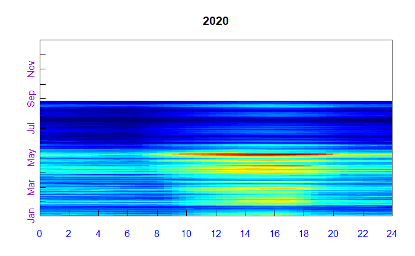

#Estimating the uncertainty of aggregated results #The results of the different u∗ threshold scenarios can be used for estimating the uncertainty due to not knowing the threshold.

#First, the mean of the GPP across all the year is computed for each u∗-scenario and converted from μmolCO2m−2s−1 to gCm−2yr−1.

```r
FilledEddyData <- eddyC$sExportResults()
uStarSuffixes <- colnames(eddyC$sGetUstarScenarios())[-1]
#suffix <- uStarSuffixes[2]
GPPAggCO2 <- sapply( uStarSuffixes, function(suffix) {
    GPPHalfHour <- FilledEddyData[[paste0("GPP_",suffix,"_f")]]
    mean(GPPHalfHour, na.rm = TRUE)
})
molarMass <- 12.011
GPPAgg <- GPPAggCO2 * 1e-6 * molarMass * 3600*24*365.25
print(GPPAgg)
```

```
    uStar       U05       U50       U95
1041.4162  987.6637 1034.8653 1067.1551
```

#The difference between those aggregated values is a first estimate of uncertainty range in GPP due to uncertainty of the u∗ threshold.

```r
(max(GPPAgg) - min(GPPAgg)) / median(GPPAgg)
```

```
[1] 0.0765709
```

#For a better but more time consuming uncertainty estimate, specify a larger sample of u∗ threshold values, for each repeat the post-processing, and compute statistics from the larger sample of resulting GPP columns. This can be achieved by specifying a larger sequence of quantiles when calling sEstimateUstarScenarios in place of the command shown above.

```r
eddyC$sEstimateUstarScenarios(
  nSample = 200, probs = seq(0.025,0.975,length.out = 39) )
```

[output not shown]

|  | uStar | 2.5% | 5% | 7.5% | 10% | 12.5% | 15% | 17.5% | 20% | 22.5% | 25% | 27.5% | 30% | 32.5% | 35% | 37.5% | 40% | 42.5% | 45% | 47.5% | 50% | 52.5% | 55% | 57.5% | 60% | 62.5% | 65% | 67.5% | 70% | … |
| --- | --- | --- | --- | --- | --- | --- | --- | --- | --- | --- | --- | --- | --- | --- | --- | --- | --- | --- | --- | --- | --- | --- | --- | --- | --- | --- | --- | --- | --- | --- |
| 1 | 0.136993 | 0.1087047 | 0.1132019 | 0.1140504 | 0.1154513 | 0.1173741 | 0.1181702 | 0.1191927 | 0.1206738 | 0.122178 | 0.1237971 | 0.1248058 | 0.1256112 | 0.1261499 | 0.1266163 | 0.1276506 | 0.1281953 | 0.1286603 | 0.1290135 | 0.1295488 | 0.1303296 | 0.131188 | 0.1318811 | 0.1331467 | 0.1339358 | 0.1347794 | 0.1357797 | 0.1367075 | 0.1371542 | … |

```
Estimated UStar distribution of:

by using  200 bootstrap samples and controls:
                       taClasses                    UstarClasses
                              7                              20
                          swThr            minRecordsWithinTemp
                             10                             100
         minRecordsWithinSeason            minRecordsWithinYear
                            160                            3000
isUsingOneBigSeasonOnFewRecords
                              1
```

#exporting dat

```r
FilledEddyData <- eddyC$sExportResults()
CombinedData <- cbind(EddyData.F, FilledEddyData)

write.csv(CombinedData, 'C:/Users/Tommy/flux/Data-exploring/02_Concord/07_Gap_Filled_Data\\gapfilled_data.csv' )

fWriteDataframeToFile(CombinedData, 'DE-Tha-Results.txt', Dir = tempdir())
```

#gap filing first three lines by Housen.

```r
# # EProc1 <- sEddyProc$new(case, data.work, c(h.ls[1]),DTS.n = d.hr)
# #         EProc1$sFillInit(h.ls[1])
# #         data.work$H_F <- EProc1$sFillMDC(7)$VAR_f
#
# #+++ Add time stamp in POSIX time format
# EddyDataWithPosix <- fConvertTimeToPosix(
#   eddy.data, 'YDH',Year = 'Year',Day = 'DoY', Hour = 'Hour') %>%
#   filterLongRuns("NEE")
#
#  EProc1 <- sEddyProc$new(
#   'Concord', EddyDataWithPosix, c('NEE','Rg','Tair','VPD', 'Ustar'))
```